# Excercise Prediction Using Classification Models

A. Wihler

3/04/2018

#### Synopsis

This analysis attempts to predict the manner in which a series of exercises were performed using accelerometer data on the belt, forearm, arm, and dumbbell of 6 participants[^1].

The primary modelling methodology is random forest, but the analysis also includes and compares the random forest accuracy to classification tree and bagging (of classification trees). The random forest model demonstrates the highest prediction accuracy and is used for the prediction of the test data.

#### R Libraries

```r
library(dplyr)
library(ggplot2)
library(rpart)
library(rpart.plot)
library(randomForest)
```

#### Getting the Data

##### Loading Data from Source

The training and test data sets are downloaded using the URLs defined in *fileURL1* and *fileURL2*, respectively. The data is located in a directory under the working directory (*./data*). If the *.csv* data files are already in the directory, the downloading step is skipped.

```r
if(!file.exists("./data/pml-training.csv")){
    print("downloading .....")
    fileURL1 <- paste0("https://d396qusza40orc.cloudfront.net/predmachlearn",
                       "/pml-training.csv")
    download.file(fileURL1,destfile = "./data/pml-training.csv")
    print("data zip file successfully downloaded")
}
```

```r
if(!file.exists("./data/pml-testing.csv")){
    print("downloading .....")
    fileURL2 <- paste0("https://d396qusza40orc.cloudfront.net/predmachlearn",
                       "/pml-testing.csv")
    download.file(fileURL2,destfile = "./data/pml-testing.csv")
    print("data zip file successfully downloaded")
}
```

##### Reading Data into Workspace

After downloading the *.csv* data files, the data is read into the current working directory.

```r
if(!exists("pml_training")){
    print("downloading .....")
    pml_training <- read.csv(paste0(getwd(),"/data/pml-training.csv"),
                             na.strings = "NA")
    print("pml_training downloaded")
}
```

```r
if(!exists("pml_testing")){
    print("downloading .....")
    pml_testing <- read.csv(paste0(getwd(),"/data/pml-testing.csv"),
                            na.strings = "NA")
    print("pml_testing downloaded")
}
```

#### Data Exploration & Cleaning

A first view of both the training and testing data sets reveal a diverse mixture of different data types. A number of variables include `NA`, `#DIV/0` or simply a blank entry. Both data sets also include metadata that needs to be excluded from the model training and prediction steps.

```r
str(pml_testing, strict.width="cut", list.len=15)
```

```
## 'data.frame':    20 obs. of  160 variables:
##  $ X                       : int  1 2 3 4 5 6 7 8 9 10 ...
##  $ user_name               : Factor w/ 6 levels "adelmo","carlitos",..: 6..
##  $ raw_timestamp_part_1    : int  1323095002 1322673067 1322673075 132283..
##  $ raw_timestamp_part_2    : int  868349 778725 342967 560311 814776 5106..
##  $ cvtd_timestamp          : Factor w/ 11 levels "02/12/2011 13:33",..: 5..
##  $ new_window              : Factor w/ 1 level "no": 1 1 1 1 1 1 1 1 1 1 ..
##  $ num_window              : int  74 431 439 194 235 504 485 440 323 664 ..
##  $ roll_belt               : num  123 1.02 0.87 125 1.35 -5.92 1.2 0.43 0..
##  $ pitch_belt              : num  27 4.87 1.82 -41.6 3.33 1.59 4.44 4.15 ..
##  $ yaw_belt                : num  -4.75 -88.9 -88.5 162 -88.6 -87.7 -87.3..
##  $ total_accel_belt        : int  20 4 5 17 3 4 4 4 4 18 ...
##  $ kurtosis_roll_belt      : logi  NA NA NA NA NA NA ...
##  $ kurtosis_picth_belt     : logi  NA NA NA NA NA NA ...
##  $ kurtosis_yaw_belt       : logi  NA NA NA NA NA NA ...
##  $ skewness_roll_belt      : logi  NA NA NA NA NA NA ...
##   [list output truncated]
```

```r
str(pml_training, strict.width="cut", list.len=15)
```

```
## 'data.frame':    19622 obs. of  160 variables:
##  $ X                       : int  1 2 3 4 5 6 7 8 9 10 ...
##  $ user_name               : Factor w/ 6 levels "adelmo","carlitos",..: 2..
##  $ raw_timestamp_part_1    : int  1323084231 1323084231 1323084231 132308..
##  $ raw_timestamp_part_2    : int  788290 808298 820366 120339 196328 3042..
##  $ cvtd_timestamp          : Factor w/ 20 levels "02/12/2011 13:32",..: 9..
##  $ new_window              : Factor w/ 2 levels "no","yes": 1 1 1 1 1 1 1..
##  $ num_window              : int  11 11 11 12 12 12 12 12 12 12 ...
##  $ roll_belt               : num  1.41 1.41 1.42 1.48 1.48 1.45 1.42 1.42..
##  $ pitch_belt              : num  8.07 8.07 8.07 8.05 8.07 8.06 8.09 8.13..
##  $ yaw_belt                : num  -94.4 -94.4 -94.4 -94.4 -94.4 -94.4 -94..
##  $ total_accel_belt        : int  3 3 3 3 3 3 3 3 3 3 ...
##  $ kurtosis_roll_belt      : Factor w/ 397 levels "","#DIV/0!","-0.01685"..
##  $ kurtosis_picth_belt     : Factor w/ 317 levels "","#DIV/0!","-0.02188"..
##  $ kurtosis_yaw_belt       : Factor w/ 2 levels "","#DIV/0!": 1 1 1 1 1 1..
##  $ skewness_roll_belt      : Factor w/ 395 levels "","#DIV/0!","-0.00309"..
##   [list output truncated]
```

The metadata variables include information such as user name, time stamping, etc. These variables are listed together in `meta_data` and are removed from the data sets.

```r
meta_data = c('X', 'user_name', 'raw_timestamp_part_1', 'raw_timestamp_part_2', 'cvtd_timestamp', 'new_window', 'num_window')
```

```r
`%ni%` <- Negate(`%in%`)
pml_train_data <- subset(pml_training, select = names(pml_training) %ni% meta_data)
pml_test_data <- subset(pml_testing, select = names(pml_testing) %ni% meta_data)
```

```r
pml_features <- colnames(pml_test_data)[apply(!is.na(pml_test_data), 2, any)]
```

In addition, a comparison is made between the *test* and *training* data sets to determine any data set unique variable.

```r
var_diff_testtotrain <- setdiff(colnames(pml_testing), colnames(pml_training))
var_diff_traintotest <- setdiff(colnames(pml_training), colnames(pml_testing))
```

| pml_testing | problem_id |
| --- | --- |
| pml_training | classe |

The comparison shows that the variable **problem_id** is included in the *testing* data, but not in the *training* data, and the variable **classe** is included only in the *training* data set. The variable **classe** is the *predicted* variable and the variable **problem_id** is used to identify the test cases in the final prediction analysis.

To use **pml_features** for extracting out all relevant variables from the *training* data, the variable **problem_id** must first be removed as it does not exist in the *training* data set.

```r
pml_features <-  pml_features[!pml_features %in% c("problem_id")]
```

The variables defined in **pml_features** are then applied to the *training* data set. The variable **classe** is retained and positioned as the first variable in the new data set (**pml_train_clean**).

```r
pml_train_clean <- pml_train_data %>%
    select("classe",pml_features)
```

This step is also applied to the *test* data for visualisation purposes only. For the final prediction only the original **pml_testing** data set is used.

```r
pml_test_clean <- pml_test_data %>%
    select("problem_id", pml_features)
```

In removing the `NA` data, and retaining only on those variables provided in the *test* data set, all the other undesirable data including `#DIV/0` have been removed.

```r
str(pml_test_clean, strict.width="cut", list.len=10)
```

```
## 'data.frame':    20 obs. of  53 variables:
##  $ problem_id          : int  1 2 3 4 5 6 7 8 9 10 ...
##  $ roll_belt           : num  123 1.02 0.87 125 1.35 -5.92 1.2 0.43 0.93 ..
##  $ pitch_belt          : num  27 4.87 1.82 -41.6 3.33 1.59 4.44 4.15 6.72..
##  $ yaw_belt            : num  -4.75 -88.9 -88.5 162 -88.6 -87.7 -87.3 -88..
##  $ total_accel_belt    : int  20 4 5 17 3 4 4 4 4 18 ...
##  $ gyros_belt_x        : num  -0.5 -0.06 0.05 0.11 0.03 0.1 -0.06 -0.18 0..
##  $ gyros_belt_y        : num  -0.02 -0.02 0.02 0.11 0.02 0.05 0 -0.02 0 0..
##  $ gyros_belt_z        : num  -0.46 -0.07 0.03 -0.16 0 -0.13 0 -0.03 -0.0..
##  $ accel_belt_x        : int  -38 -13 1 46 -8 -11 -14 -10 -15 -25 ...
##  $ accel_belt_y        : int  69 11 -1 45 4 -16 2 -2 1 63 ...
##   [list output truncated]
```

```r
str(pml_train_clean, strict.width="cut", list.len=10)
```

```
## 'data.frame':    19622 obs. of  53 variables:
##  $ classe              : Factor w/ 5 levels "A","B","C","D",..: 1 1 1 1 1..
##  $ roll_belt           : num  1.41 1.41 1.42 1.48 1.48 1.45 1.42 1.42 1.4..
##  $ pitch_belt          : num  8.07 8.07 8.07 8.05 8.07 8.06 8.09 8.13 8.1..
##  $ yaw_belt            : num  -94.4 -94.4 -94.4 -94.4 -94.4 -94.4 -94.4 -..
##  $ total_accel_belt    : int  3 3 3 3 3 3 3 3 3 3 ...
##  $ gyros_belt_x        : num  0 0.02 0 0.02 0.02 0.02 0.02 0.02 0.02 0.03..
##  $ gyros_belt_y        : num  0 0 0 0 0.02 0 0 0 0 0 ...
##  $ gyros_belt_z        : num  -0.02 -0.02 -0.02 -0.03 -0.02 -0.02 -0.02 -..
##  $ accel_belt_x        : int  -21 -22 -20 -22 -21 -21 -22 -22 -20 -21 ...
##  $ accel_belt_y        : int  4 4 5 3 2 4 3 4 2 4 ...
##   [list output truncated]
```

The *cleaned* training data set (**pml_train_clean**) retains all 19622 observations of the original data set (**pml_training**), but with only 53 versus the original 160 variables. The 53 variables includes 52 predictor variables plus the predicted variable **classe**.

#### Create Training and Testing Data

For training and validating the model, the training data is split into the **model_train** and **model_test** data sets. The split uses a 70/30 ratio.

```r
set.seed(180301)
samp <- sample(nrow(pml_train_clean), 0.7 * nrow(pml_train_clean))
model_train <- pml_train_clean[samp, ]
model_test <- pml_train_clean[-samp, ]
```

##### Index for Prediction Variable

The column index of the predicted variable **classe** is retrieved from the training data set. This information is used to exclude the predicted variable in the prediction steps.

```r
typeColNum <- grep("classe", names(pml_train_clean))
```

### Model Construction & Analysis

The model design is be based on classification tree and random forest. The initial model will attempt to fit the data to a single *(pruned) classification tree*. This will follow with *bagging* (bootstrap aggregation) of classification trees and finally a *random forest*. All 52 variables are used in model training. Finally a method is shown to evaluate if any variable can be removed from the random forest model.

#### Classification Tree

```r
set.seed(180301)
pml_ct <- rpart(classe ~ ., method="class", data = model_train)
```

##### Complexity Table

The complexity table indicates that the classification tree uses 15 of the 52 variables.

```r
printcp(pml_ct)
```

```
##
## Classification tree:
## rpart(formula = classe ~ ., data = model_train, method = "class")
##
## Variables actually used in tree construction:
##  [1] accel_dumbbell_y     accel_dumbbell_z     accel_forearm_x
##  [4] magnet_belt_z        magnet_dumbbell_y    magnet_dumbbell_z
##  [7] magnet_forearm_z     pitch_belt           pitch_forearm
## [10] roll_belt            roll_dumbbell        roll_forearm
## [13] total_accel_dumbbell yaw_belt             yaw_forearm
##
## Root node error: 9827/13735 = 0.71547
##
## n= 13735
##
##          CP nsplit rel error  xerror      xstd
## 1  0.116719      0   1.00000 1.00000 0.0053809
## 2  0.060615      1   0.88328 0.88328 0.0057516
## 3  0.036227      4   0.70143 0.70673 0.0059626
## 4  0.027679      5   0.66521 0.67131 0.0059584
## 5  0.019742      6   0.63753 0.64028 0.0059420
## 6  0.018978      7   0.61779 0.53292 0.0057925
## 7  0.017808     13   0.47573 0.49323 0.0056991
## 8  0.014043     14   0.45792 0.46148 0.0056085
## 9  0.013738     15   0.44388 0.44866 0.0055678
## 10 0.011194     16   0.43014 0.42088 0.0054710
## 11 0.010990     17   0.41895 0.39442 0.0053675
## 12 0.010481     20   0.37712 0.38455 0.0053259
## 13 0.010380     21   0.36664 0.37865 0.0053003
## 14 0.010176     22   0.35626 0.37031 0.0052630
## 15 0.010000     23   0.34609 0.36847 0.0052546
```

The complexity parameter `CP` (also referred to as $\alpha$) is used to determine whether a split contributes to a better model fit. The value is varied in the pruning step and set to the smallest cross validation error (`xerror`).

##### Cross-Validation

The value of the cross validation error versus the complexity parameter and tree size is visualised using `plotcp()`.

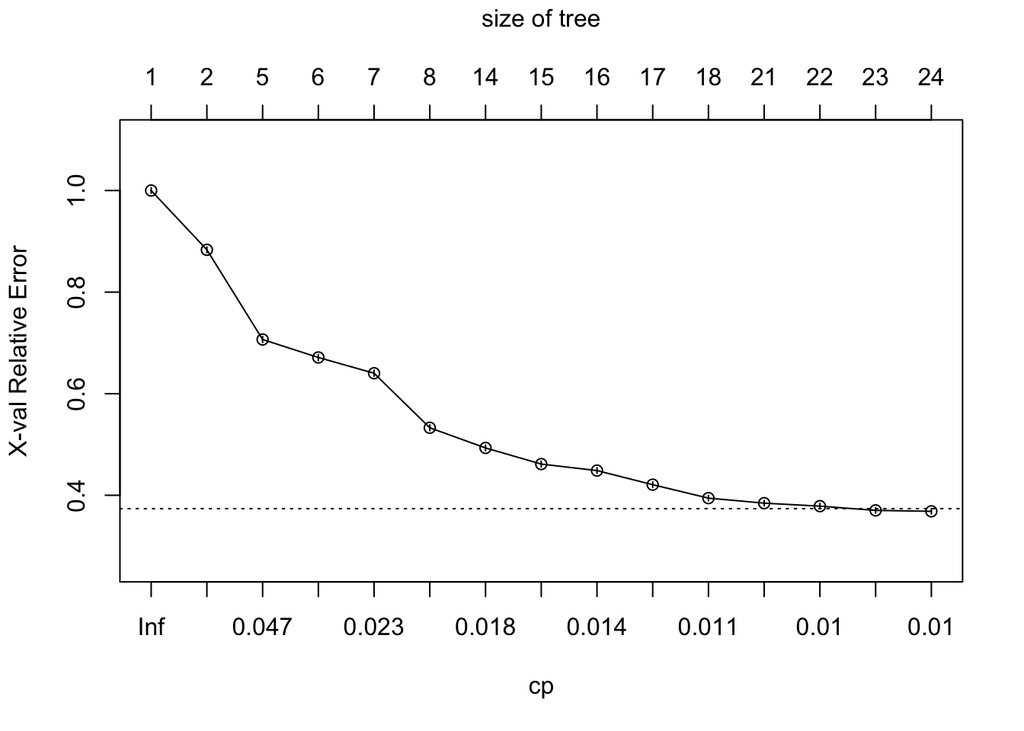

```r
plotcp(pml_ct)
```

##### Prune the tree

The best complexity parameter is selected corresponding to the lowest cross validation error.

```r
bestcp <- pml_ct$cptable[which.min(pml_ct$cptable[,"xerror"]),"CP"]
bestcp
```

```
## [1] 0.01
```

In this case, the value is very close to zero, so no relevant impact from pruning is expected.

```r
set.seed(180301)
pml_ctp<- prune(pml_ct, cp=bestcp)
```

##### Prediction

The pruned classification tree is tested using the validation data set split from the training data set.

```r
pr_pml_ctp <- predict(pml_ctp, type="class", newdata=model_test[,-typeColNum])
```

##### Confusion Matrix & Prediction Accuracy

```r
conf_matrix <- table(pr_pml_ctp, model_test$classe)
colnames(conf_matrix) <- paste(colnames(conf_matrix), "-actual", sep = "")
rownames(conf_matrix) <- paste(rownames(conf_matrix), "-predicted", sep = "")
```

```r
prediction.accuracy <- mean(pr_pml_ctp==model_test$classe)
misclassification.rate <- 1-mean(pr_pml_ctp==model_test$classe)
```

|  | A-actual | B-actual | C-actual | D-actual | E-actual |
| --- | --- | --- | --- | --- | --- |
| A-predicted | 1472 | 169 | 11 | 71 | 21 |
| B-predicted | 66 | 657 | 47 | 91 | 115 |
| C-predicted | 46 | 115 | 892 | 161 | 150 |
| D-predicted | 69 | 89 | 63 | 629 | 58 |
| E-predicted | 19 | 58 | 51 | 46 | 721 |

| prediction.accuracy | misclassification.rate |
| --- | --- |
| 74.2 | 25.8 |

#### Bagging (Classification Tree)

Bagging generates multiple models by taking repeated samples from a (single) training data set using bootstrap. A decision tree is trained on each bootstrapped training data set, and a single prediction is given by the maximum (for classification trees) of all the individual tree predictions.

To apply bagging using the `randomForest()` function, all variables to be tried at each split (`mtry`) must be forced to include all variables. In other words, `mtry` is set to 52 variables.

```r
set.seed(180301)
pml_rfb <- randomForest(classe ~., data=model_train,
                        importance=TRUE,
                        xtest=model_test[,-typeColNum],
                        mtry=ncol(model_test[,-typeColNum]),
                        ntree=500,
                        type = "class")
```

```
##
## Call:
##  randomForest(formula = classe ~ ., data = model_train, importance = TRUE,      xtest = model_test[, -typeColNum], mtry = ncol(model_test[,          -typeColNum]), ntree = 500, type = "class")
##                Type of random forest: classification
##                      Number of trees: 500
## No. of variables tried at each split: 52
##
##         OOB estimate of  error rate: 1.26%
## Confusion matrix:
##      A    B    C    D    E class.error
## A 3883   13    9    0    3 0.006397134
## B   30 2655   17    6    1 0.019933555
## C    3   20 2321   13    1 0.015691264
## D    1    4   32 2177    4 0.018485122
## E    0    2    5    9 2526 0.006294256
```

The model output indicates that all 52 variables were evaluated at each split.

##### Error vs Number of Trees

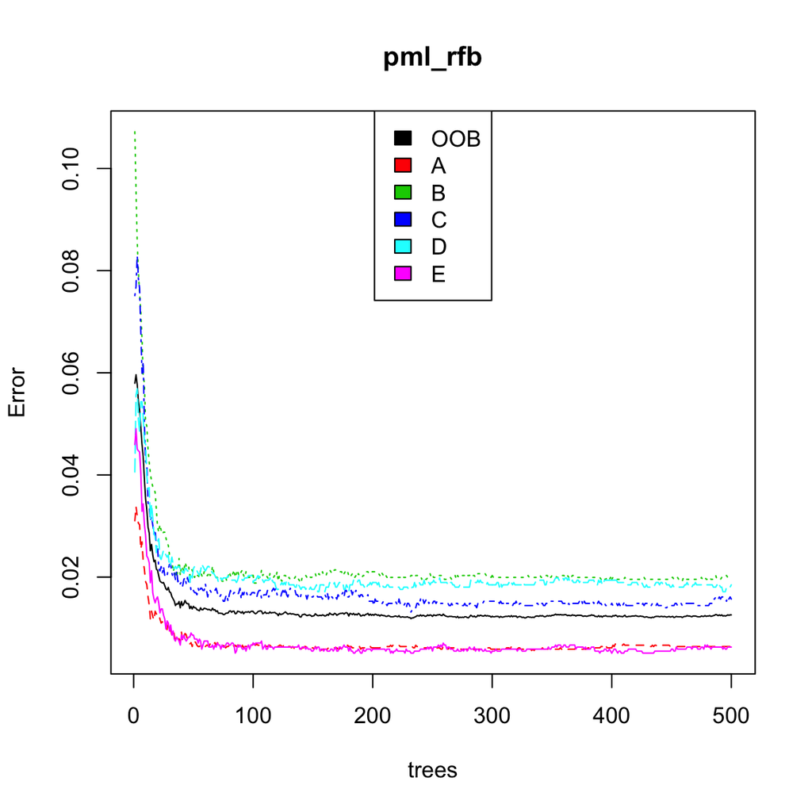

```r
plot(pml_rfb)
legend("top", colnames(pml_rfb$err.rate), fill = 1:6)
```

##### Confusion Matrix & Prediction Accuracy

The bagging procedure demonstrates a significant improvement in prediction accuracy over the single classification tree (98.7% for bagging versus 74.2% for the classification tree).

```r
conf_matrix <- table(pml_rfb$test$predicted, model_test$classe)
colnames(conf_matrix) <- paste(colnames(conf_matrix), "(actual)", sep = " ")
rownames(conf_matrix) <- paste("Pred", rownames(conf_matrix), sep = ":")
```

```r
prediction.accuracy <- mean(pml_rfb$test$predicted==model_test$classe)
misclassification.rate <- 1-mean(pml_rfb$test$predicted==model_test$classe)
```

|  | A (actual) | B (actual) | C (actual) | D (actual) | E (actual) |
| --- | --- | --- | --- | --- | --- |
| Pred:A | 1668 | 14 | 2 | 1 | 0 |
| Pred:B | 2 | 1065 | 8 | 1 | 9 |
| Pred:C | 1 | 9 | 1047 | 20 | 1 |
| Pred:D | 1 | 0 | 7 | 975 | 2 |
| Pred:E | 0 | 0 | 0 | 1 | 1053 |

| prediction.accuracy | misclassification.rate |
| --- | --- |
| 98.7 | 1.3 |

#### Random Forest

The random forest algorithm also applies the bagging procedure, but in addition also includes a random subset of predictor variables when splitting nodes during tree construction. Each time a split is considered, a random sample of predictors is chosen from the full set of predictor variables. The number of variables used each time is nominally given by the square-root of the total number of variables ($\sim \sqrt{p}$) which is also the default setting for the `randomforest()` algorithm.

```r
set.seed(180301)
pml_rf <- randomForest(classe ~., data=model_train,
                        importance=TRUE,
                        xtest=model_test[,-typeColNum],
                        ntree=500,
                        type = "class",
                        keep.forest=TRUE)
```

```
##
## Call:
##  randomForest(formula = classe ~ ., data = model_train, importance = TRUE,      xtest = model_test[, -typeColNum], ntree = 500, type = "class",      keep.forest = TRUE)
##                Type of random forest: classification
##                      Number of trees: 500
## No. of variables tried at each split: 7
##
##         OOB estimate of  error rate: 0.5%
## Confusion matrix:
##      A    B    C    D    E class.error
## A 3904    2    1    0    1 0.001023541
## B   12 2691    6    0    0 0.006644518
## C    0   13 2342    3    0 0.006785411
## D    1    0   23 2192    2 0.011722272
## E    0    0    1    4 2537 0.001966955
```

The output from `randomForest()` confirms that the number of variables tried at each split is $\sim \sqrt{p}$ or `mtry` = 7.

##### Error vs Number of Trees

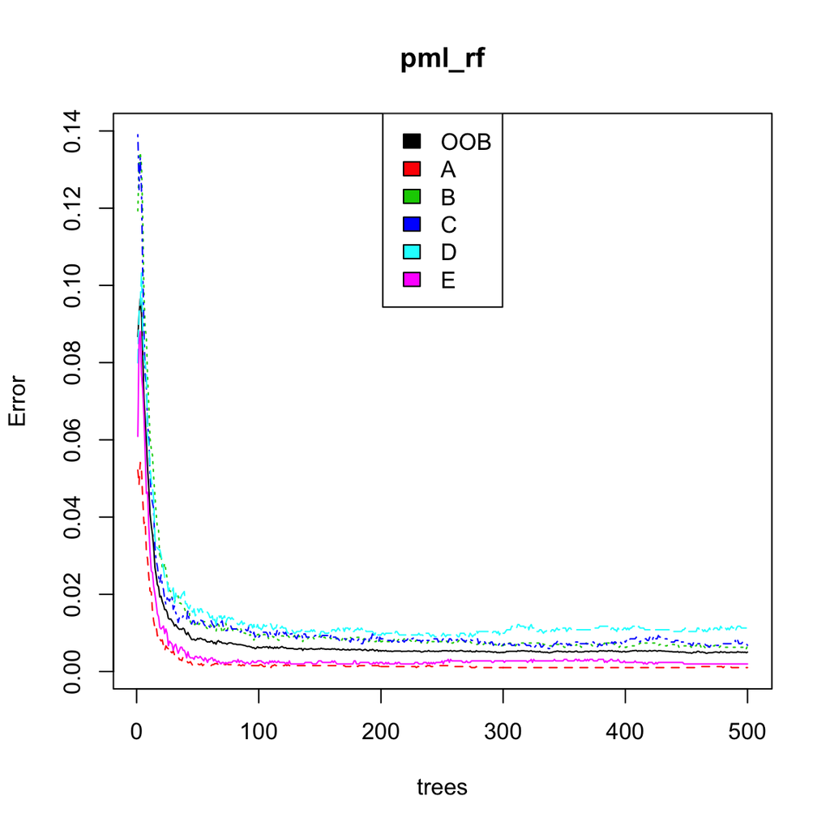

```r
plot(pml_rf)
legend("top", colnames(pml_rf$err.rate), fill = 1:6)
```

##### Confusion Matrix & Prediction Accuracy

The random forest algorithm shows further improvement in prediction accuracy over the bagging procedure (99.5% for random forest versus 98.7% for bagging). The relative prediction accuracy between the random forest and bagging algorithms can also be visualised by examination of the confusion matrices. The number of misclassified (off-diagonal) events are visibly lower in the random forest confusion matrix.

```r
conf_matrix <- table(pml_rf$test$predicted, model_test$classe)
colnames(conf_matrix) <- paste(colnames(conf_matrix), "(actual)", sep = " ")
rownames(conf_matrix) <- paste("Pred", rownames(conf_matrix), sep = ":")
```

```r
prediction.accuracy <- mean(pml_rf$test$predicted==model_test$classe)
misclassification.rate <- 1-mean(pml_rf$test$predicted==model_test$classe)
```

|  | A (actual) | B (actual) | C (actual) | D (actual) | E (actual) |
| --- | --- | --- | --- | --- | --- |
| Pred:A | 1672 | 8 | 0 | 0 | 0 |
| Pred:B | 0 | 1077 | 2 | 0 | 0 |
| Pred:C | 0 | 3 | 1060 | 12 | 1 |
| Pred:D | 0 | 0 | 2 | 986 | 1 |
| Pred:E | 0 | 0 | 0 | 0 | 1063 |

| prediction.accuracy | misclassification.rate |
| --- | --- |
| 99.5 | 0.5 |

#### Random Forest with Selected Predictors

The number of trees (`ntree`) and the number of variables to be considered for splitting (`mtry`) were examined, but the number of predictor variables have not yet been considered. Running a model with fewer predictors may help interpretation and save on computational effort.

There are a number of different methods to help decide which variables, if any, should be removed from the model structure. One possible method is to construct the random forest after the introduction of a noise variable into the data set. Any variable that has a mean decrease in the Gini Index (`MeanDecreaseGini`) below that of the *noise* variable can be considered for disqualification as a predictor variable.

Another possibility would be to remove the variable with the lowest mean decrease in the Gini Index and repeat the Random Forest model build. If the prediction accuracy (test data) improves, select the next lowest variable and repeat. if there is no change or no increase in the prediction accuracy, the iteration stops.

##### Introduce Noise Variable into Data Set

A noise variable is introduced using the numeric range of the data set.

```r
data_range <- range(model_train[,-typeColNum])
model_train_n <- data.frame(model_train, noise = sample(c(data_range[1]:data_range[2]), nrow(model_train), replace = TRUE))
model_test_n <- data.frame(model_test, noise = sample(c(data_range[1]:data_range[2]), nrow(model_test), replace = TRUE))
```

##### Random Forest with Noise Variable

```r
set.seed(180301)
pml_rfn <- randomForest(classe ~., data=model_train_n,
                        importance=TRUE,
                        xtest=model_test_n[, -typeColNum],
                        ntree=500,
                        type = "class",
                        keep.forest=TRUE)
```

```
##
## Call:
##  randomForest(formula = classe ~ ., data = model_train_n, importance = TRUE,      xtest = model_test_n[, -typeColNum], ntree = 500, type = "class",      keep.forest = TRUE)
##                Type of random forest: classification
##                      Number of trees: 500
## No. of variables tried at each split: 7
##
##         OOB estimate of  error rate: 0.58%
## Confusion matrix:
##      A    B    C    D    E class.error
## A 3904    3    1    0    0 0.001023541
## B   17 2685    7    0    0 0.008859358
## C    0   13 2341    4    0 0.007209500
## D    0    0   24 2192    2 0.011722272
## E    0    0    3    6 2533 0.003540519
```

##### Variable Importance

All variables including the **noise** variable are shown in the Variable Importance Plot. From inspection, the noise variable has the lowest mean decrease in the Gini index and therefore *none* of the measured predictor variables can be removed based on this method.

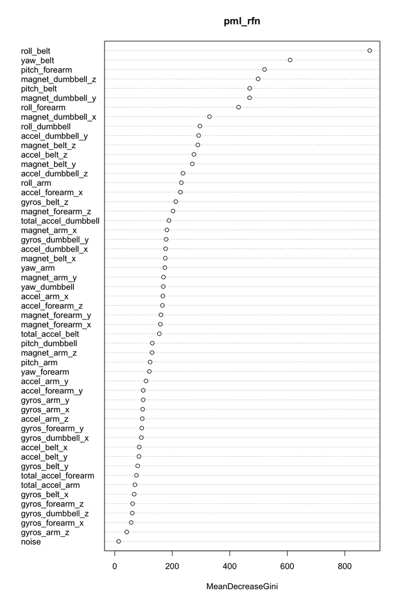

```r
varImpPlot(pml_rfn, type=2, n.var=ncol(model_train_n[, -typeColNum]))
```

#### Model Comparison

The random forest algorithm has demonstrated superior predictive capabilities over the classification tree and bagging. The prediction exercise using the given test data set is, therefore, performed using the random forest model.

|  | prediction.accuracy |
| --- | --- |
| classification tree | 74.2 |
| bagging (classification tree) | 98.7 |
| random forest | 99.5 |

### Prediction on the Test Data

```r
pml_prediction <- predict(pml_rf, newdata=pml_testing, type = "class")
```

|  | 1 | 2 | 3 | 4 | 5 | 6 | 7 | 8 | 9 | 10 | 11 | 12 | 13 | 14 | 15 | 16 | 17 | 18 | 19 | 20 |
| --- | --- | --- | --- | --- | --- | --- | --- | --- | --- | --- | --- | --- | --- | --- | --- | --- | --- | --- | --- | --- |
| pml_prediction | B | A | B | A | A | E | D | B | A | A | B | C | B | A | E | E | A | B | B | B |

[^1]: Velloso, E.; Bulling, A.; Gellersen, H.; Ugulino, W.; Fuks, H. Qualitative Activity Recognition of Weight Lifting Exercises. Proceedings of 4th International Conference in Cooperation with SIGCHI (Augmented Human ’13) . Stuttgart, Germany: ACM SIGCHI, 2013.